# Assignment: Homework Hyndman Chapter 5 & 6 Exercises

## Question 6

`#` Question 6 (a) Use an STL decomposition to calculate the trend-cycle and seasonal indices. (Experiment with having fixed or changing seasonality.)

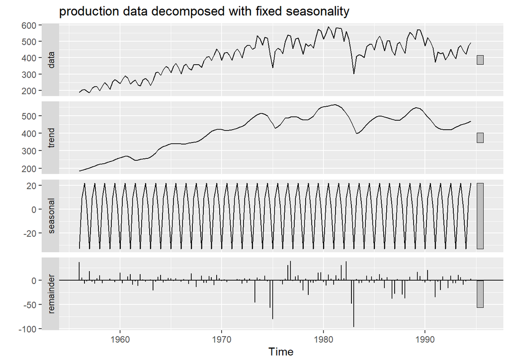

```r
#fixed seasonality
stl.fixed.st <- stl(bricksq,
                          s.window = "periodic",
                          robust = TRUE)
autoplot(stl.fixed.st) +
  ggtitle("production data decomposed with fixed seasonality")
```

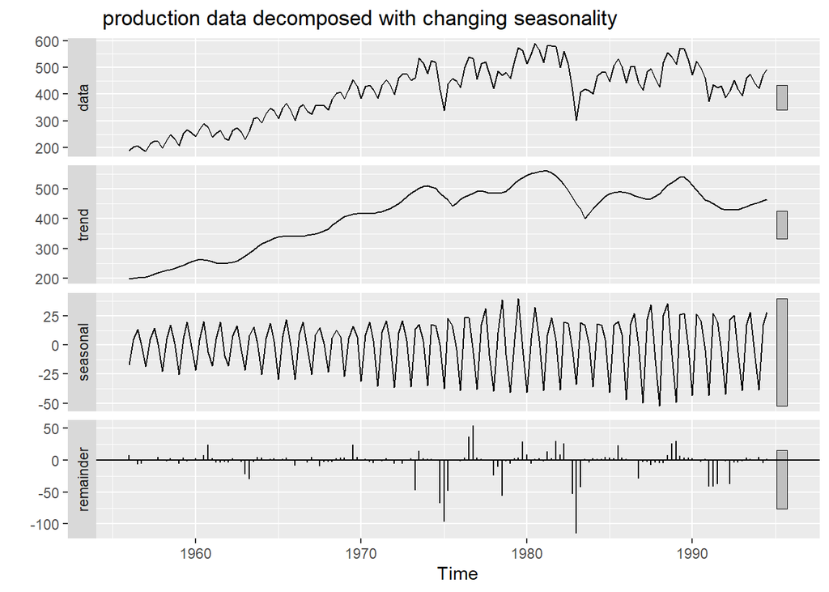

```r
#  changing seasonality
stl.changing.st <- stl(bricksq,
                             s.window = 5,
                             robust = TRUE)

autoplot(stl.changing.st) +
  ggtitle(" production data decomposed with changing seasonality")
```

`#` Question 6 (b) Compute and plot the seasonally adjusted data.

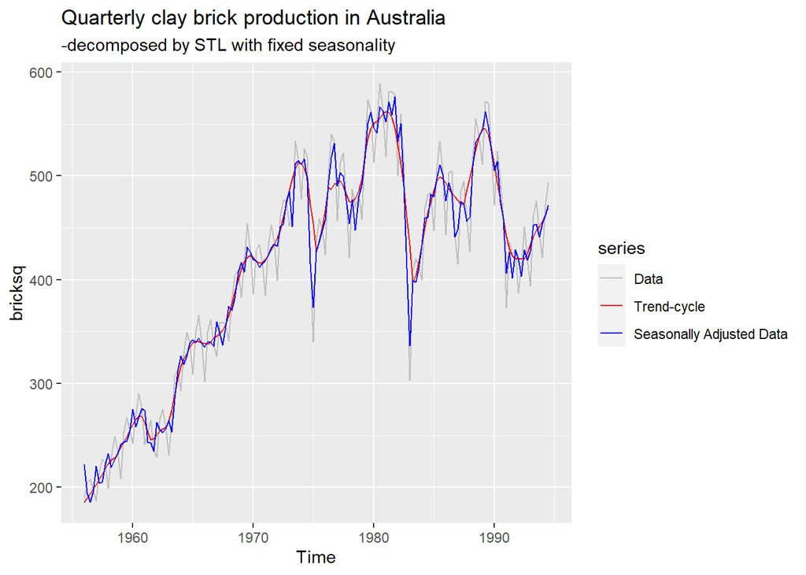

```r
autoplot(bricksq, series = "Data") +
  autolayer(trendcycle(stl.fixed.st),
            series = "Trend-cycle") +
  autolayer(seasadj(stl.fixed.st),
            series = "Seasonally Adjusted Data") +
  ggtitle("Quarterly clay brick production in Australia",
          subtitle = "-decomposed by STL with fixed seasonality") +
  scale_color_manual(values = c("gray", "red", "blue"),
                     breaks = c("Data", "Trend-cycle", "Seasonally Adjusted Data"))
```

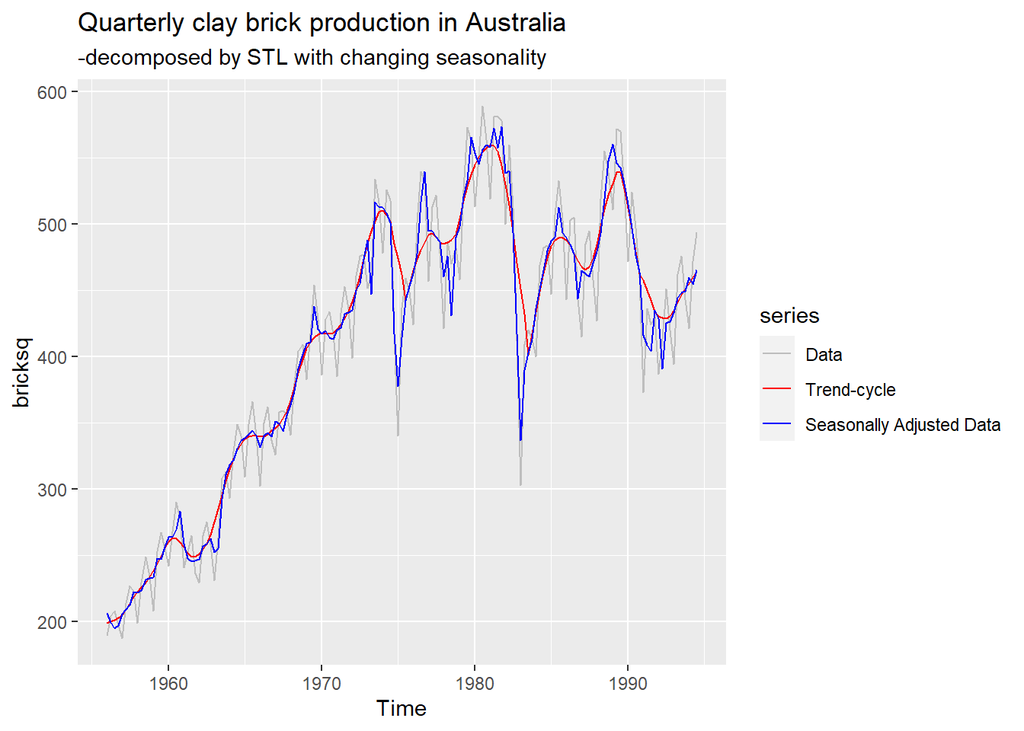

```r
# plot data which are decomposed  with changing seasonality
autoplot(bricksq, series = "Data") +
  autolayer(trendcycle(stl.changing.st),
            series = "Trend-cycle") +
  autolayer(seasadj(stl.changing.st),
            series = "Seasonally Adjusted Data") +
  ggtitle("Quarterly clay brick production in Australia",
          subtitle = "-decomposed by STL with changing seasonality") +
  scale_color_manual(values = c("gray", "red", "blue"),
                     breaks = c("Data", "Trend-cycle", "Seasonally Adjusted Data"))
```

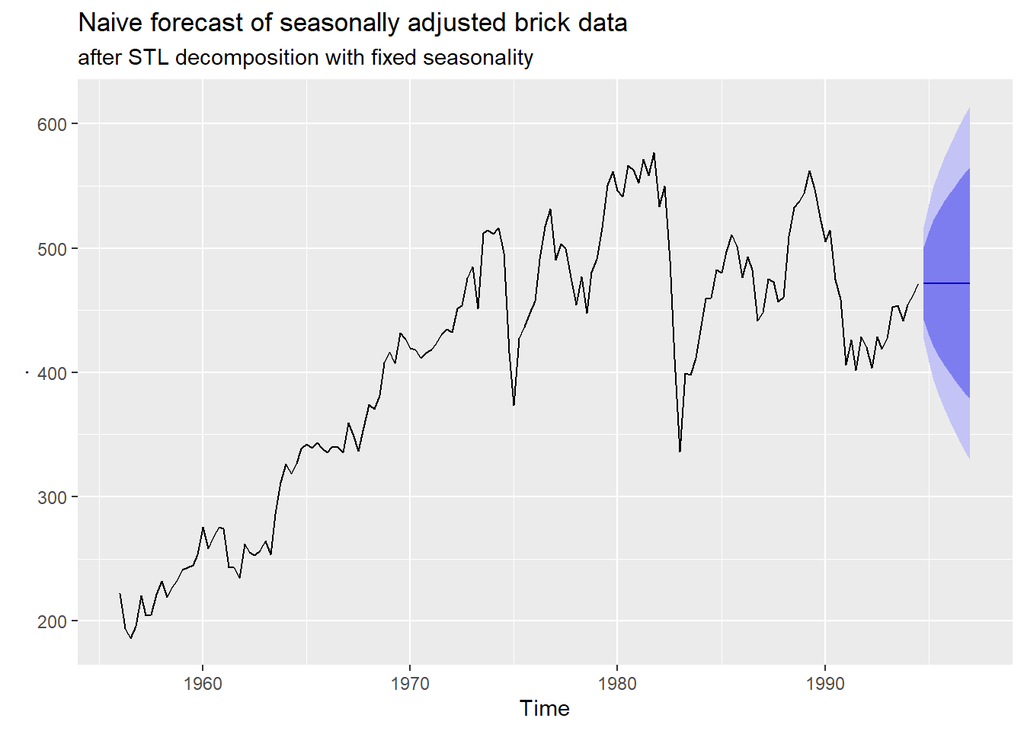

```r
stl.fixed.st %>% seasadj() %>% naive() %>% autoplot() +
  ggtitle(label = "Naive forecast of seasonally adjusted brick data",
          subtitle = "after STL decomposition with fixed seasonality")
```

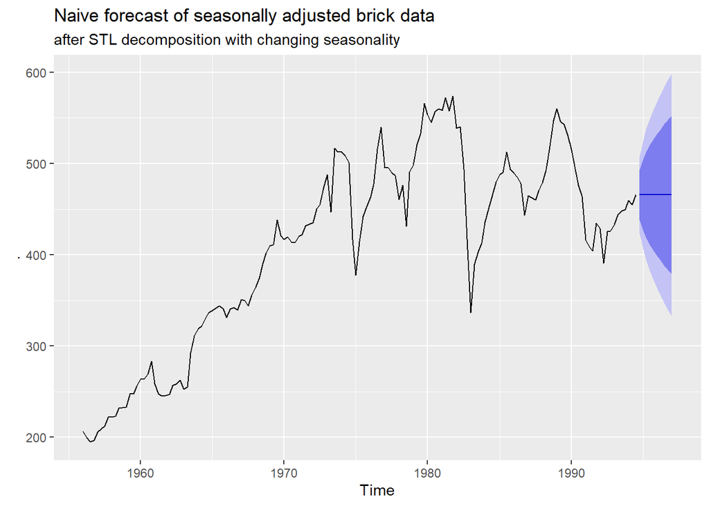

```r
stl.changing.st %>% seasadj() %>% naive() %>% autoplot() +
  ggtitle(label = "Naive forecast of seasonally adjusted brick data",
          subtitle = "after STL decomposition with changing seasonality")
```

The range of the decomposed with changing seasonalit alsmost similer to the decomposed with fixed seasonality.

`#` Question 6 (d) Use stlf() to reseasonalise the results, giving forecasts for the original data.

```r
brick.t <- stlf(bricksq)
brick.t
```

```
##         Point Forecast    Lo 80    Hi 80    Lo 95    Hi 95
## 1994 Q4       467.0636 439.0835 495.0437 424.2718 509.8555
## 1995 Q1       426.0736 386.4842 465.6629 365.5268 486.6203
## 1995 Q2       484.0345 435.5220 532.5470 409.8411 558.2280
## 1995 Q3       493.9988 437.9514 550.0462 408.2817 579.7159
## 1995 Q4       467.0636 404.3669 529.7604 371.1772 562.9500
## 1996 Q1       426.0736 357.3555 494.7916 320.9784 531.1688
## 1996 Q2       484.0345 409.7703 558.2988 370.4571 597.6119
## 1996 Q3       493.9988 414.5638 573.4338 372.5134 615.4841
```

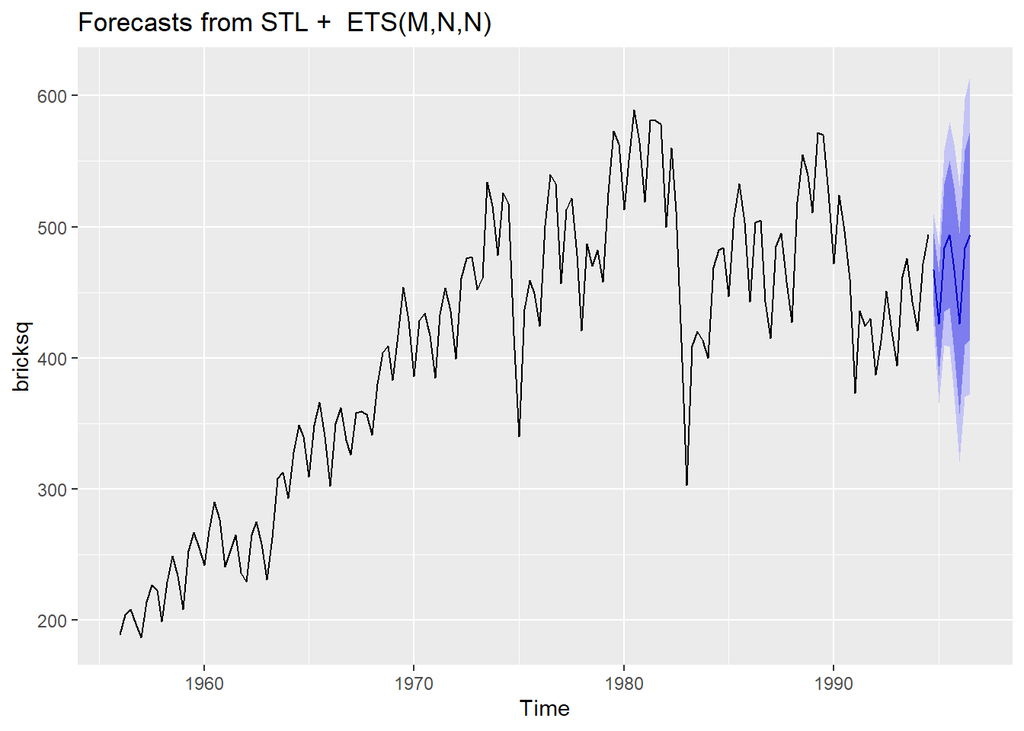

```r
autoplot(brick.t)
```

`#` Question 6 (e) Do the residuals look uncorrelated?

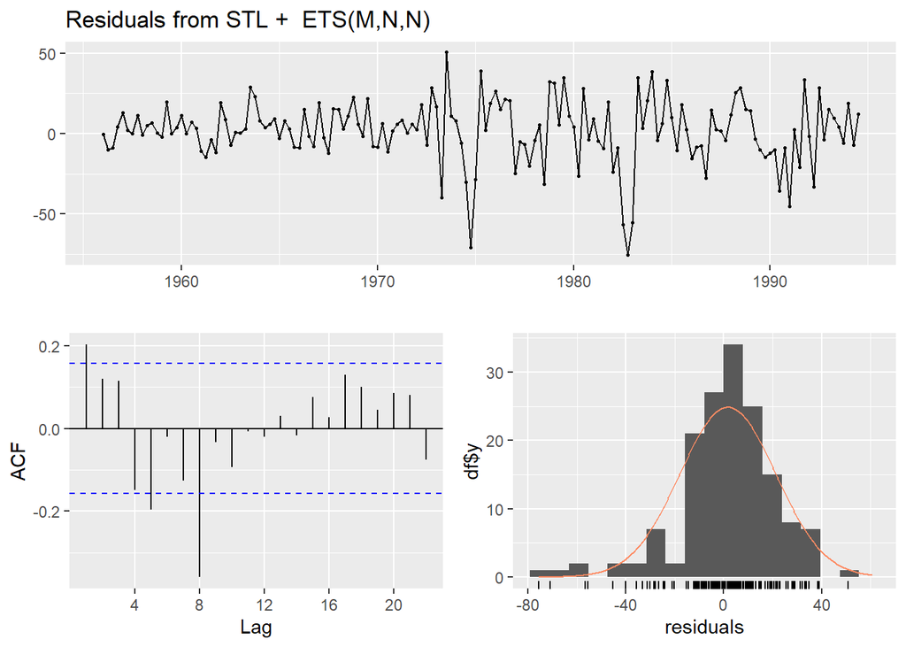

```
##
##  Ljung-Box test
##
## data:  Residuals from STL +  ETS(M,N,N)
## Q* = 44.704, df = 6, p-value = 5.358e-08
##
## Model df: 2.   Total lags used: 8
```

```r
checkresiduals(brick.t)
```

residuals are correlated with each other

`#` Question 6 (f) Repeat with a robust STL decomposition. Does it make much difference?

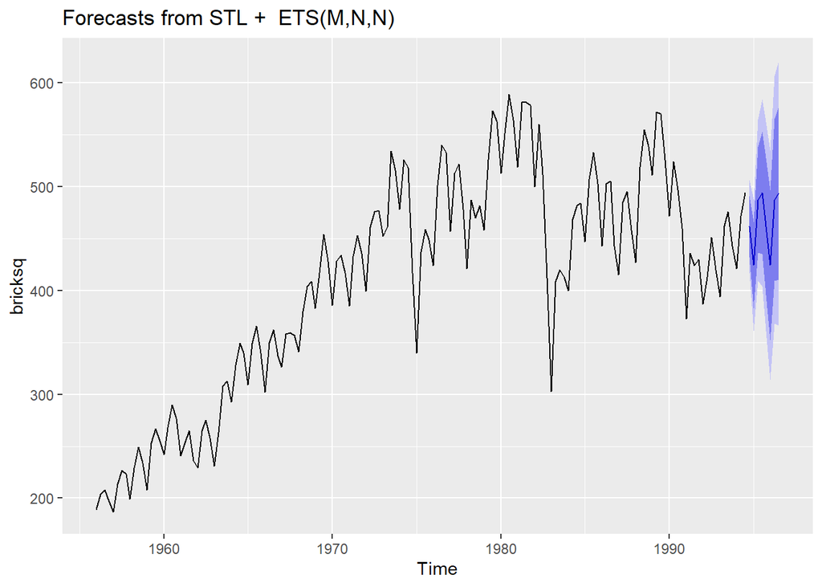

```r
brick.tt <-  stlf(bricksq, robust = TRUE)
autoplot(brick.tt)
```

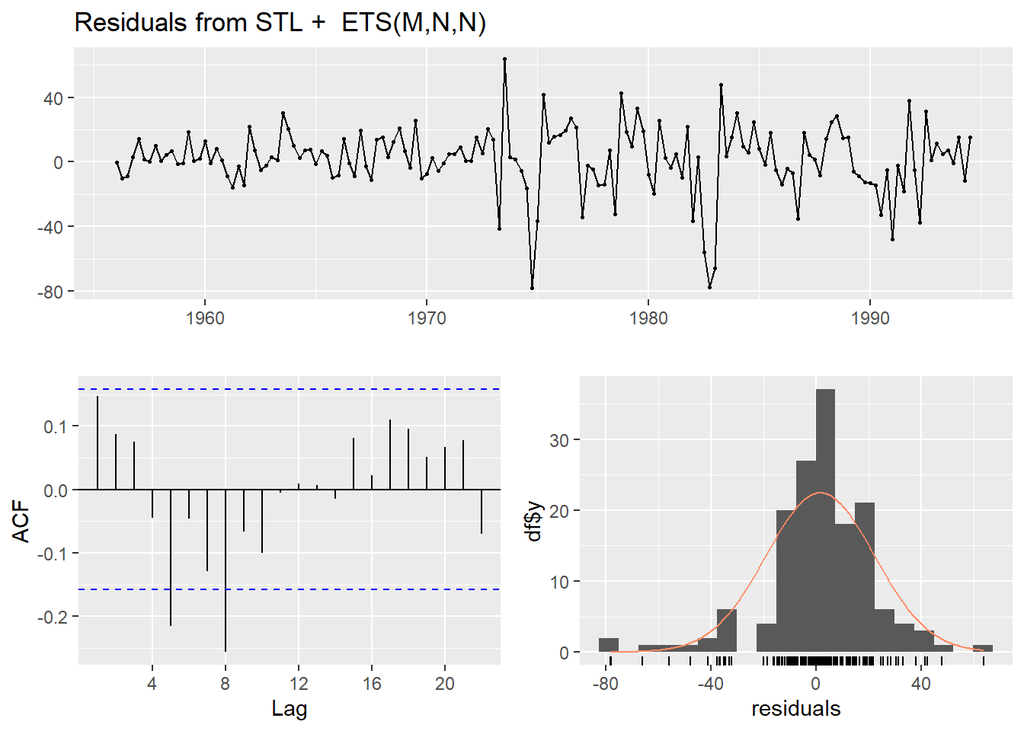

```
##
##  Ljung-Box test
##
## data:  Residuals from STL +  ETS(M,N,N)
## Q* = 27.278, df = 6, p-value = 0.0001284
##
## Model df: 2.   Total lags used: 8
```

```r
checkresiduals(brick.tt)
```

we can see there are still correlation even with the robust

`#` Question 6 (g) Compare forecasts from`stlf()`with those from`snaive()`,using a test set comprising the last 2 years of data. Which is better?

```r
trainset.brick <- subset(bricksq,
                        end = length(bricksq) - 8)
testset.brick <- subset(bricksq,
                        start = length(bricksq) - 7)
snaive.brick <- snaive(trainset.brick)
stlf.brick <- stlf(trainset.brick, robust = TRUE)


snaive.brick
```

```
##         Point Forecast    Lo 80    Hi 80    Lo 95    Hi 95
## 1992 Q4            430 366.2905 493.7095 332.5647 527.4353
## 1993 Q1            387 323.2905 450.7095 289.5647 484.4353
## 1993 Q2            413 349.2905 476.7095 315.5647 510.4353
## 1993 Q3            451 387.2905 514.7095 353.5647 548.4353
## 1993 Q4            430 339.9011 520.0989 292.2056 567.7944
## 1994 Q1            387 296.9011 477.0989 249.2056 524.7944
## 1994 Q2            413 322.9011 503.0989 275.2056 550.7944
## 1994 Q3            451 360.9011 541.0989 313.2056 588.7944
```

```r
stlf.brick
```

```
##         Point Forecast    Lo 80    Hi 80    Lo 95    Hi 95
## 1992 Q4       425.1830 398.0913 452.2746 383.7499 466.6160
## 1993 Q1       376.9049 338.5697 415.2401 318.2763 435.5336
## 1993 Q2       443.5569 396.5777 490.5361 371.7084 515.4054
## 1993 Q3       450.9969 396.7168 505.2771 367.9826 534.0113
## 1993 Q4       425.1830 364.4585 485.9074 332.3129 518.0530
## 1994 Q1       376.9049 310.3434 443.4664 275.1079 478.7019
## 1994 Q2       443.5569 371.6178 515.4961 333.5355 553.5783
## 1994 Q3       450.9969 374.0430 527.9508 333.3061 568.6877
```

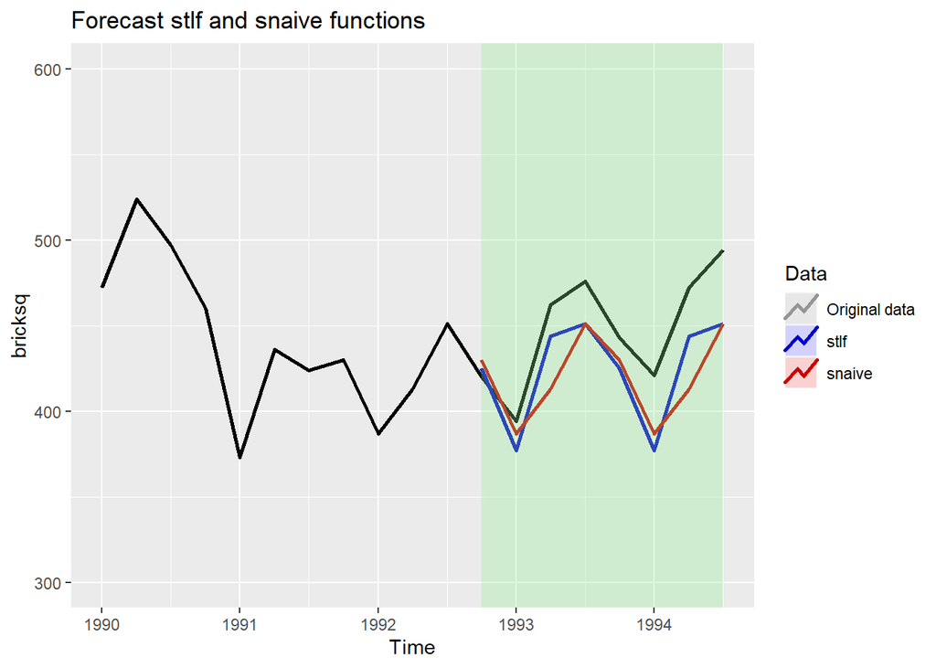

```r
autoplot(bricksq, series = "Original data") +
  geom_line(size = 1) +
  autolayer(stlf.brick, PI = FALSE, size = 1,
            series = "stlf") +
  autolayer(snaive.brick, PI = FALSE, size = 1,
            series = "snaive") +
  scale_color_manual(values = c("gray50", "blue", "red"),
                     breaks = c("Original data", "stlf", "snaive")) +
  scale_x_continuous(limits = c(1990, 1994.5)) +
  scale_y_continuous(limits = c(300, 600)) +
  guides(colour = guide_legend(title = "Data")) +
  ggtitle("Forecast stlf and snaive functions") +
  annotate(
    "rect",
    xmin=1992.75,xmax=1994.5,ymin=-Inf,ymax=Inf,
    fill="lightgreen",alpha = 0.3
    )
```

## Question 7

Use`stlf()`to produce forecasts of the`writing`series with either`method="naive"`or`method="rwdrift"`,whichever is most appropriate. Use the`lambda`argument if you think a Box-Cox transformation is required.

I think is it would be better to use`rwdrift`method to forecast non-seasonal component

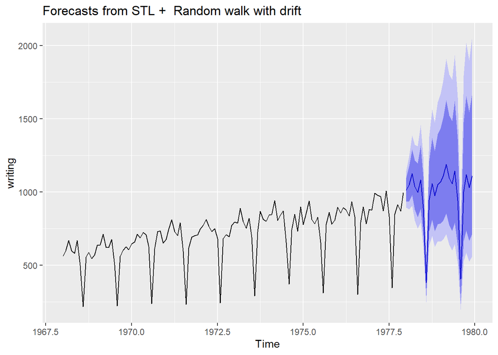

```r
writingBC <- stlf(writing,
                  method='rwdrift',
                  robust=TRUE,
                  lambda = BoxCox.lambda(writing)

                  )
autoplot(writingBC)
```

## Question 8

Use`stlf()`to produce forecasts of the`fancy`series with either`method="naive"`or`method="rwdrift"`,whichever is most appropriate. Use the`lambda`argument if you think a Box-Cox transformation is required.

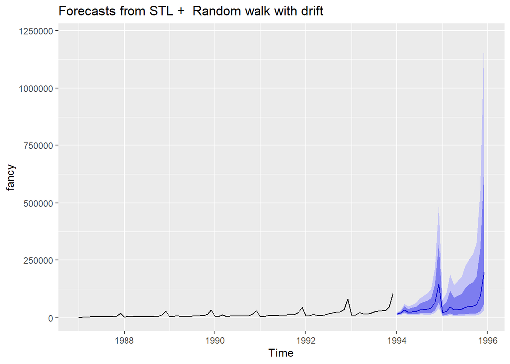

```r
stlf.fancy <- stlf(fancy,
                   robust = TRUE,
                   lambda = BoxCox.lambda(fancy),
                   method = "rwdrift")
autoplot(stlf.fancy)
```

because of the Box-Cox transformation the intervals increase increases highly